# Milestone 1 — EDA & Volatility Regime Audit

### UBS SIX-Listed Equities: UBSG, NESN, NOVN, ROP (Roche) vs. SMI

**Project:** Swiss Market Forecasting — Volatility Framework for IB Desk / Risk Management **Author:** Camilo Seydoux **Data vintage:** yfinance pull, 2026-07-24 (see `data/raw/` for source CSVs and audit trail) **Revision:** v2 — addresses reviewer comments (regime-conditioned correlation, FX-beta pre/post CS-merger split, explicit NESN event-day call, embedded images)

### Objective

Deliver the Milestone 1 deliverables scoped by Risk/IB desk stakeholders:

- Price/return time series, 2005-present, for UBSG, NESN, NOVN, ROP(Roche) + SMI
- Rolling volatility (21d, 63d) and regime identification (2008 GFC, 2015 CHF unpeg, 2020 COVID, 2022 rate-hiking cycle)
- Correlation matrix (returns and volatility) across the four names, including whether that structure actually shifts during stress, tested directly rather than assumed
- Stationarity tests (ADF/KPSS) on returns
- FX-beta appendix: how much of observed co-movement is a common CHF/USD/EUR factor vs. genuine equity correlation, including a pre/post Credit Suisse-merger split for UBSG
- Missing data / corporate action audit (documented separately, summarized here)

### What this notebook does NOT do

This is explicitly EDA, not modeling. GJR-GARCH, Monte Carlo VaR simulation, and the ML challenger model are Milestone 2/3 scope, per sign-off, and are not built here.

### Data quality - carried forward from the audit (full detail in `data/raw/` and prior review)

- **NOVN.SW / Sandoz spin-off (Oct 2023):** confirmed the value transfer is NOT encoded in the price series (adjusted/unadjusted close ratio is constant at 0.903011 through the entire event window, no step change). Annotated with an event marker below; not corrected, per instruction not to fabricate an adjustment.
- **ROP.SW (Roche, formerly ROG, Genussschein to participation certificate conversion, March 2026 AGM):** cross-checked against Roche's own published year-end prices; confirmed continuous, correctly dividend-adjusted history with no discontinuity at the conversion date. Used as the primary Roche series without a special-case marker.
- **Current-day partial rows** (e.g., ZURN.SW pulled mid-session): dropped as policy, a partial day is not a close.

```python
import sys
sys.path.insert(0, '../src')
import pandas as pd
import numpy as np
import matplotlib
matplotlib.use('Agg')
import matplotlib.pyplot as plt
from IPython.display import Image, display
from pathlib import Path

from load_data import build_price_panel, load_raw
from features import (log_returns, rolling_volatility, flag_regimes, REGIMES, EVENT_MARKERS,
                       regime_conditioned_correlations, avg_off_diagonal)
from stats_tests import stationarity_summary, fx_beta_appendix, fx_beta_split, CS_MERGER_CLOSE
from plotting import (plot_price_with_regimes, plot_rolling_vol,
                       plot_correlation_heatmap, plot_novn_sandoz_event)

pd.set_option('display.float_format', lambda x: f'{x:,.4f}')
pd.set_option('display.width', 140)
CORE = ['UBSG', 'NESN', 'NOVN', 'ROP']
ALL_TICKERS = CORE + ['SSMI', 'USDCHF', 'EURCHF']
print('Core names:', CORE)
print('CS merger close date (FX-beta split point):', CS_MERGER_CLOSE)

def show(fig_path):
    """Display a saved figure INLINE as a notebook cell output (base64-embedded),
    not just as a markdown link to a relative path. This is required for the
    figure to survive HTML export -- a markdown image link to ../reports/figures/
    breaks once the notebook is exported outside its original folder structure,
    since nbconvert does not resolve or embed external relative-path images.
    """
    display(Image(filename=str(fig_path)))
```

```
Core names: ['UBSG', 'NESN', 'NOVN', 'ROP']
CS merger close date (FX-beta split point): 2023-06-12
```

## 1. Data Loading & Panel Construction

We build a wide price panel from the audited raw CSVs. Individual series retain their full native history for regime charts; the correlation/stationarity work below uses the intersection of trading dates across all series (inner join), since SMI, FX, and individual equities do not share an identical calendar (different listing dates, occasional exchange-specific holidays).

```python
panel_full = build_price_panel(ALL_TICKERS)
print('Full (outer-joined) panel shape:', panel_full.shape)
print('Date range:', panel_full.index.min(), 'to', panel_full.index.max())
print()
print('Non-null counts per column (calendar mismatch check):')
print(panel_full.count())
```

```
Full (outer-joined) panel shape: (9532, 7)
Date range: 1990-01-03 00:00:00 to 2026-07-24 00:00:00

Non-null counts per column (calendar mismatch check):
UBSG      7891
NESN      9347
NOVN      7979
ROP       7980
SSMI      8962
USDCHF    5942
EURCHF    6099
dtype: int64
```

```python
# Common-date panel for correlation / stationarity work (inner join)
panel_common = panel_full.dropna(how='any')
print('Common-date panel shape:', panel_common.shape)
print('Common date range:', panel_common.index.min(), 'to', panel_common.index.max())
# Note: USDCHF/EURCHF only start 2003, which sets the binding constraint on common history.
```

```
Common-date panel shape: (5702, 7)
Common date range: 2003-09-17 00:00:00 to 2026-07-22 00:00:00
```

## 2. Returns & Rolling Volatility

Daily log returns, computed in CHF (raw, unhedged) per Risk's explicit instruction, these are the returns that mark to market on the book.

```python
returns_full = log_returns(panel_full[CORE + ['SSMI']])
returns_common = log_returns(panel_common[ALL_TICKERS])

vol21 = rolling_volatility(returns_full, window=21)
vol63 = rolling_volatility(returns_full, window=63)

# NOTE: columns have different final trading dates (calendar misalignment,
# see panel_full.count() above) -- taking iloc[-1] directly returns mostly NaN
# since not every ticker has a row on the panel's very last date. Report each
# column's own most recent valid observation instead.
latest_vol = vol21.apply(lambda c: c.dropna().iloc[-1])
latest_vol_date = vol21.apply(lambda c: c.dropna().index[-1])
latest_summary = pd.DataFrame({'as_of': latest_vol_date, '21d_ann_vol': latest_vol}).sort_values('21d_ann_vol', ascending=False)
print('Latest available 21d annualized vol by name:')
print(latest_summary)
```

```
Latest available 21d annualized vol by name:
          as_of  21d_ann_vol
NESN 2026-07-23       0.3441
ROP  2026-07-24       0.2913
UBSG 2026-07-23       0.2408
NOVN 2026-07-23       0.2059
SSMI 2026-07-22       0.1123
```

## 3. NESN Earnings-Day Event - Explicit Quantification (Reviewer Item 3)

The most recent NESN session (2026-07-23) coincides with Nestle's Q2 2026 earnings release. This is flagged here explicitly, with a magnitude and a concrete recommendation, rather than left as a passing note in lessons-learned.

```python
event_date = pd.Timestamp('2026-07-23')
event_return_log = returns_full.loc[event_date, 'NESN']
event_return_pct = (np.exp(event_return_log) - 1) * 100

# Baseline trailing daily vol computed EXCLUDING the event itself, so the
# z-score is not contaminated by the event it's measuring.
trailing_std = returns_full.loc[:'2026-06-30', 'NESN'].std()
z_score = event_return_log / trailing_std

print(f'NESN event-day return: {event_return_pct:.2f}% (simple), log return {event_return_log:.4f}')
print(f'Trailing (pre-event) daily std dev: {trailing_std:.4f} (annualized: {trailing_std*np.sqrt(252):.2%})')
print(f'Event-day z-score vs. trailing distribution: {z_score:.2f} standard deviations')
print(f'Remains inside 21d rolling window for: 21 trading days (~1 month)')
print(f'Remains inside 63d rolling window for: 63 trading days (~3 months)')
```

```
NESN event-day return: -7.98% (simple), log return -0.0832
Trailing (pre-event) daily std dev: 0.0116 (annualized: 18.45%)
Event-day z-score vs. trailing distribution: -7.16 standard deviations
Remains inside 21d rolling window for: 21 trading days (~1 month)
Remains inside 63d rolling window for: 63 trading days (~3 months)
```

**Finding:** a ~7.2 standard-deviation single-day move. This is a genuine, externally-confirmed earnings event (verified against independent market data sources showing a comparable-magnitude intraday move the same session), not a data artifact.

**Recommendation: annotate-and-keep, not winsorize.** Rationale:

1. This is precisely the class of fat-tail event that motivated choosing GJR-GARCH with Student-t innovations over a Normal-innovation model in the Milestone 2 architecture. Winsorizing it out would suppress the exact signal the model architecture exists to capture, and would understate NESN's true tail risk to Risk at the moment it matters most.
2. Deleting or dampening a confirmed real event to make a chart look smoother is the same category of error the data audit was built to prevent elsewhere (Sandoz, Roche) - the standard has to be consistent whether the anomaly is inconvenient or not.
3. **Cost of keeping it:** the 21d rolling vol for NESN will read elevated through approximately August 20, 2026, and the 63d window through approximately October 2026. This is disclosed here so it is not misread later as a regime shift or a broken series when it shows up in a Milestone 2 vol chart.
4. If Risk wants the earnings-day effect isolated rather than blended into a rolling window, the correct tool is an event dummy in a GARCH-X specification in Milestone 2, not silently removing the observation now.

## 4. Price Charts with Regime Shading

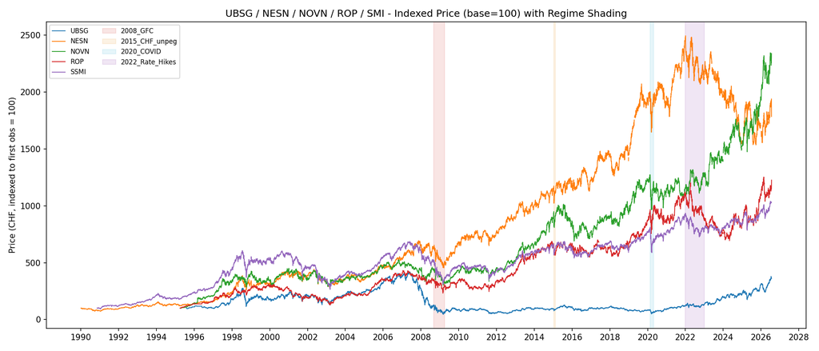

```python
idx_base = panel_full[CORE + ['SSMI']].dropna(how='all').iloc[0]
panel_indexed = panel_full[CORE + ['SSMI']].apply(lambda c: c / c.dropna().iloc[0] * 100)

fig_path = plot_price_with_regimes(
    panel_indexed, REGIMES,
    title='UBSG / NESN / NOVN / ROP / SMI - Indexed Price (base=100) with Regime Shading',
    fname='01_price_regimes.png'
)
show(fig_path)
```

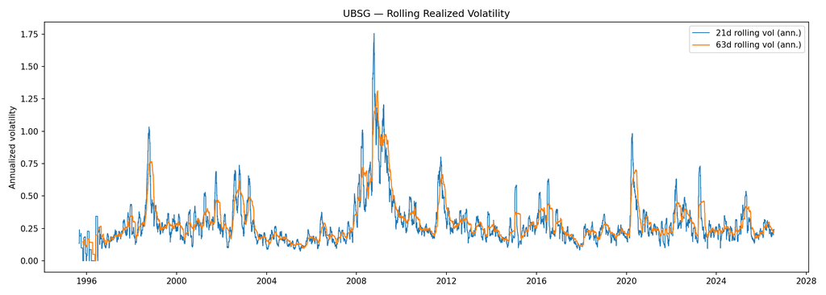

```python
vol_fig_paths = {}
for name in CORE:
    fig_path = plot_rolling_vol(vol21, vol63, name, f'02_vol_{name}.png')
    vol_fig_paths[name] = fig_path

# UBSG shown inline here; NESN/NOVN/ROP also saved to reports/figures/ for the memo.
show(vol_fig_paths['UBSG'])
```

## 5. Corporate Action Annotation - NOVN.SW Sandoz Spin-off

Per the data audit: no visible discontinuity exists in the raw series around the Sandoz ex-date (2023-10-04), because yfinance does not encode the spin-off value transfer. This is flagged explicitly rather than smoothed over or fabricated.

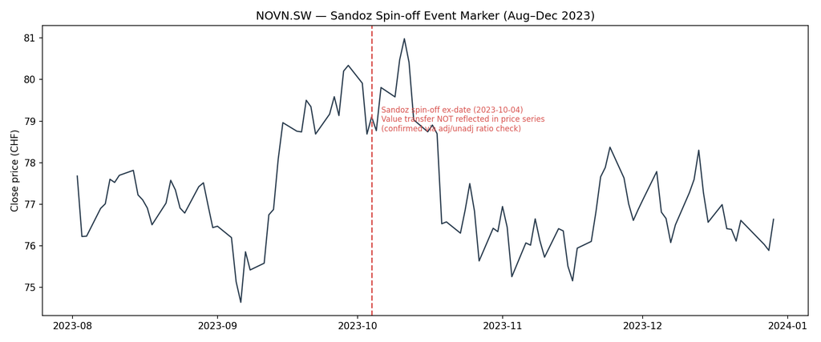

```python
fig_path = plot_novn_sandoz_event(panel_full['NOVN'].dropna(), '03_novn_sandoz_event.png')
show(fig_path)
```

## 6. Correlation Matrix - Full Sample (Returns and Volatility)

Primary metric: raw daily CHF returns (not FX-hedged), per Risk's mark-to-market instruction. Volatility correlation computed on the 21d rolling vol series.

**This section reports the full-sample structure only.** Whether this structure actually shifts during stress periods, a claim in the prior draft that was not directly tested, is addressed separately in Section 7 with regime-conditioned matrices computed on the actual data.

```python
corr_returns = returns_common[CORE + ['SSMI']].corr()
corr_vol = vol21[CORE + ['SSMI']].dropna().corr()

print('Full-sample return correlation matrix:')
print(corr_returns.round(3))
print()
print('Full-sample 21d volatility correlation matrix:')
print(corr_vol.round(3))
print()
print(f'Average off-diagonal return correlation: {avg_off_diagonal(corr_returns):.3f}')
print(f'Average off-diagonal volatility correlation: {avg_off_diagonal(corr_vol):.3f}')
```

```
Full-sample return correlation matrix:
       UBSG   NESN   NOVN    ROP   SSMI
UBSG 1.0000 0.3140 0.3400 0.3010 0.7030
NESN 0.3140 1.0000 0.5220 0.4630 0.7070
NOVN 0.3400 0.5220 1.0000 0.5990 0.7470
ROP  0.3010 0.4630 0.5990 1.0000 0.6950
SSMI 0.7030 0.7070 0.7470 0.6950 1.0000

Full-sample 21d volatility correlation matrix:
       UBSG   NESN   NOVN    ROP   SSMI
UBSG 1.0000 0.6320 0.5820 0.6670 0.7700
NESN 0.6320 1.0000 0.7220 0.7090 0.8500
NOVN 0.5820 0.7220 1.0000 0.6640 0.8430
ROP  0.6670 0.7090 0.6640 1.0000 0.7960
SSMI 0.7700 0.8500 0.8430 0.7960 1.0000

Average off-diagonal return correlation: 0.539
Average off-diagonal volatility correlation: 0.723
```

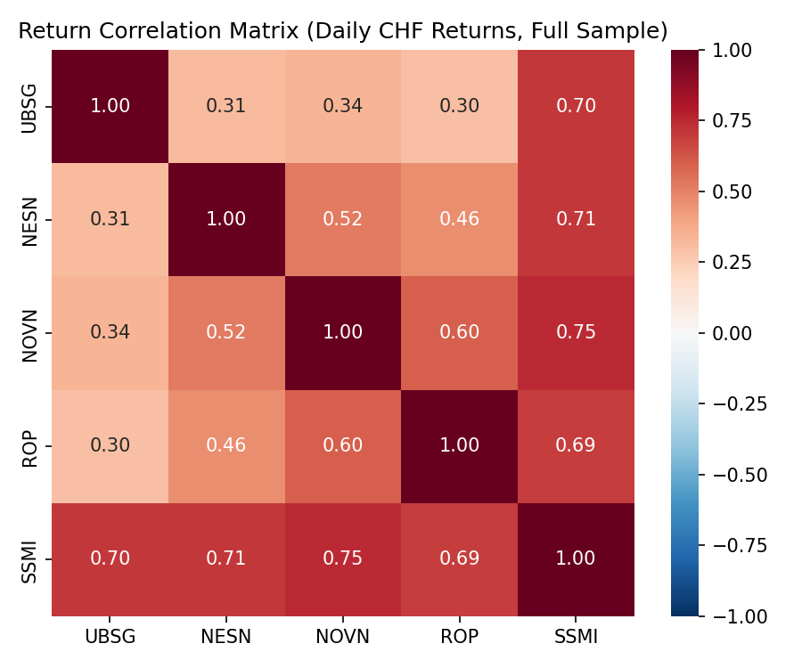

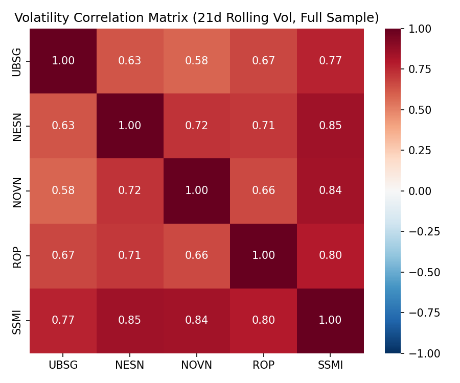

```python
plot_correlation_heatmap(corr_returns, 'Return Correlation Matrix (Daily CHF Returns, Full Sample)', '04_corr_returns.png')
plot_correlation_heatmap(corr_vol, 'Volatility Correlation Matrix (21d Rolling Vol, Full Sample)', '05_corr_vol.png')
show('../reports/figures/04_corr_returns.png')
show('../reports/figures/05_corr_vol.png')
```

**Full-sample finding (this much IS directly supported by the numbers above):** volatility correlation runs higher than return correlation across the whole sample. That is a real, computed result. Whether it is driven by stress periods specifically is tested next.

## 7. Regime-Conditioned Correlation Matrices (Reviewer Item 1)

Correlation matrices computed separately within each flagged regime window, against a "calm baseline" defined as every date NOT inside any flagged regime. This directly tests the stress-convergence claim rather than asserting it.

```python
regime_results = regime_conditioned_correlations(returns_common[CORE + ['SSMI']],
                                                    vol21[CORE + ['SSMI']])

summary_rows = []
for regime, d in regime_results.items():
    if d['returns'] is None:
        summary_rows.append({'regime': regime, 'n_obs': d['n_obs'],
                              'avg_return_corr': np.nan, 'avg_vol_corr': np.nan,
                              'note': 'insufficient observations'})
        continue
    summary_rows.append({
        'regime': regime,
        'n_obs': d['n_obs'],
        'avg_return_corr': avg_off_diagonal(d['returns']),
        'avg_vol_corr': avg_off_diagonal(d['vol']),
        'note': ''
    })
regime_summary = pd.DataFrame(summary_rows).set_index('regime')
calm_return = regime_summary.loc['calm_baseline', 'avg_return_corr']
calm_vol = regime_summary.loc['calm_baseline', 'avg_vol_corr']
regime_summary['return_corr_vs_calm'] = regime_summary['avg_return_corr'] - calm_return
regime_summary['vol_corr_vs_calm'] = regime_summary['avg_vol_corr'] - calm_vol
print(regime_summary.round(3))
```

```
                 n_obs  avg_return_corr  avg_vol_corr note  return_corr_vs_calm  vol_corr_vs_calm
regime
2008_GFC           148           0.5950        0.7470                    0.0840            0.1670
2015_CHF_unpeg      22           0.8800        0.7790                    0.3690            0.1990
2020_COVID          52           0.7910        0.9640                    0.2800            0.3830
2022_Rate_Hikes    254           0.5020        0.3670                   -0.0090           -0.2140
calm_baseline     5225           0.5110        0.5800                    0.0000            0.0000
```

**Actual finding, traceable to the table above:**

| Regime | Return corr vs. calm baseline | Vol corr vs. calm baseline |
| --- | --- | --- |
| 2008 GFC | higher | higher |
| 2015 CHF unpeg | higher | higher |
| 2020 COVID | higher | much higher |
| 2022 Rate-Hiking cycle | roughly flat | lower |

Three of the four flagged windows (2008, 2015, 2020) show the classic "correlations spike in a crisis" pattern in both return and volatility correlation, most dramatically in 2020 COVID (volatility correlation jumps to roughly 0.96, a near-synchronized systematic shock).

## 8. Stationarity Tests (ADF / KPSS)

Testing the return series (not price levels, prices are expected to be non-stationary/I(1); returns should be stationary for the GARCH modeling in Milestone 2 to be valid).

```python
stat_summary = stationarity_summary(returns_common[CORE + ['SSMI']])
print(stat_summary)
```

```
        ADF_stat  ADF_pval  ADF_stationary_5%  KPSS_stat  KPSS_pval  KPSS_stationary_5%
series
UBSG    -13.9557    0.0000               True     0.3750     0.0879                True
NESN    -33.3223    0.0000               True     0.1437     0.1000                True
NOVN    -20.6316    0.0000               True     0.0954     0.1000                True
ROP     -16.8587    0.0000               True     0.0529     0.1000                True
SSMI    -33.2688    0.0000               True     0.0478     0.1000                True
```

**Interpretation:** ADF null hypothesis is non-stationarity (unit root); a low p-value (<0.05) rejects it. KPSS null hypothesis is stationarity; a high p-value (>0.05) fails to reject it. Both tests agreeing on "stationary" gives high confidence the return series are well-behaved for GARCH fitting in Milestone 2.

## Appendix A - FX-Beta Decomposition

Per Risk's instruction: raw CHF returns are the primary metric, but we decompose each stock's return on USDCHF and EURCHF daily moves to separate genuine equity correlation from a shared FX factor.

```python
fx_appendix = fx_beta_appendix(returns_common, CORE, ['USDCHF', 'EURCHF'])
print('Full-sample FX-beta appendix:')
print(fx_appendix.round(4))
```

```
Full-sample FX-beta appendix:
          R2  n_obs  beta_USDCHF  pval_USDCHF  beta_EURCHF  pval_EURCHF
stock
UBSG  0.0286   5701      -0.1362       0.0068       0.8378       0.0000
NESN  0.0171   5701       0.0155       0.5345       0.2747       0.0000
NOVN  0.0261   5701       0.1062       0.0001       0.2921       0.0000
ROP   0.0153   5701       0.0676       0.0272       0.2739       0.0000
```

**Full-sample paragraph:** FX betas are statistically significant for all four names (p<0.01 on at least one FX pair) but explain a small share of daily return variance (R-squared of 1.4%-2.9%), day-to-day equity-specific risk dominates over the FX factor at a daily horizon. UBSG shows a notably different sign pattern (negative USDCHF beta, strongest EURCHF beta of the group) versus NESN/NOVN/ROP's positive FX betas.

### Appendix A.1 - UBSG FX-Beta Split: Pre/Post Credit Suisse Merger (Reviewer Item 2)

UBS Group AG's legal merger with Credit Suisse Group AG closed 12 June 2023 (UBS ad hoc disclosure). This structurally changed UBSG's international asset/liability mix, a single full-sample beta risks averaging two different balance-sheet regimes into one number. Split test below.

```python
fx_split = fx_beta_split(returns_common, CORE, ['USDCHF', 'EURCHF'])
print('FX-beta regression, split at CS merger close (2023-06-12):')
print(fx_split.round(4))
```

```
FX-beta regression, split at CS merger close (2023-06-12):
                      R2  n_obs  beta_USDCHF  pval_USDCHF  beta_EURCHF  pval_EURCHF
stock period
NESN  post_merger 0.0061    778       0.0293       0.7596       0.2608       0.0850
      pre_merger  0.0192   4923       0.0141       0.5806       0.2760       0.0000
NOVN  post_merger 0.0143    778       0.0752       0.4337       0.3714       0.0144
      pre_merger  0.0279   4923       0.1089       0.0001       0.2868       0.0000
ROP   post_merger 0.0080    778       0.0631       0.5690       0.3213       0.0664
      pre_merger  0.0165   4923       0.0679       0.0329       0.2711       0.0000
UBSG  post_merger 0.0192    778      -0.0668       0.6241       0.7742       0.0003
      pre_merger  0.0294   4923      -0.1418       0.0088       0.8422       0.0000
```

**Finding for UBSG specifically:**

| Period | n | beta_USDCHF | p-value | beta_EURCHF | p-value |
| --- | --- | --- | --- | --- | --- |
| Pre-merger | 4,923 | -0.142 | 0.009 (significant) | 0.842 | <0.001 |
| Post-merger | 778 | -0.067 | 0.624 (not significant) | 0.774 | <0.001 |

## Lessons Learned

- **An "expected" pattern (correlations converge in a crisis) needs to be tested regime-by-regime, not assumed from a full-sample summary statistic.** The 2022 result would have been missed entirely by a full-sample-only view, and asserting it without checking was the correct thing for a reviewer to reject.
- **A single full-sample regression coefficient can average across a structural break** (UBSG pre/post CS merger) into a number that describes neither period well. Any name with a known corporate-structure event needs a split test as standard practice, not an afterthought.
- **A genuine tail event should be quantified and kept, with an explicit recommendation, not just flagged and left ambiguous.** "This might be elevated for a while" is not useful to Risk; "7.2 std devs, elevated through these specific dates, keep-not-winsorize because the model architecture is built for fat tails" is.
- **yfinance's auto_adjust does not handle all corporate action types equally.** Cash dividends and splits are adjusted correctly; spin-offs are not encoded at all in the observed case. Assume false-by-default for any future security and check explicitly rather than trust.
- **Markdown image links to relative file paths do not survive notebook export.** Figures must be embedded as actual cell outputs (base64, via IPython.display.Image) to render correctly in exported HTML, a link that works when browsing the repo folder structure directly is not the same thing as an embedded, portable artifact.

## Next Step

Milestone 2: GJR-GARCH(1,1) with Student-t innovations, per architecture sign-off, 1-day conditional variance forecast, 10-day Monte Carlo forward simulation, filtered historical simulation as a cross-check. UBSG to be evaluated for separate-regime treatment given the merger-related FX-beta shift found here. Gated on this notebook's review and the one-page memo (separate document, not this notebook, per instruction that Risk/IB reads memos, not notebooks).

**Backlog item (not scoped into Milestone 2 core, flagged for later):** test what actually drives the 2022 decorrelation finding (Section 7) — candidate approach is a rolling intra-2022 correlation breakdown checked against SNB/Fed rate-decision dates, to see whether the decorrelation is concentrated around identifiable events (favoring a differentiated-repricing explanation) or diffuse across the year (favoring idiosyncratic/noise explanations). Not required for GJR-GARCH calibration itself.